# MLOps Monitoring Report — Pre-Production Defect Risk Scorer

Periods: Jan 2026 – Mar 2026 · Model v4 (Xgboost) ·

Section 1

## Status & Retraining Decision

The retraining decision is led by directly-measured signals (model performance and defect-rate drift) because ground-truth outcomes for this shop land within the scoring period. Prediction and feature drift act as early proxies and diagnostic context, not primary triggers. The verdict below reflects the most recent period (Mar 2026); the sections that follow show the full trend.

✓ NO ACTION REQUIRED As of Mar 2026

Model Version v4 (Xgboost)

Trained June 24, 2026

Periods Monitored Jan 2026 – Mar 2026

Reference January 2023 – December 2024

High-Tier Precision 93.8%

Defect Rate Shift 5.1%

Features Drifted 1 / 17

Trigger Reasons

Retraining rules are evaluated every period. Primary rules measure harm directly; secondary rules are leading proxies that warrant investigation rather than immediate retraining.

|  | Tier | Rule | Status |
| --- | --- | --- | --- |
| ✓ | Primary | High-tier precision below 85% (measured performance) | OK |
| ✓ | Primary | Defect rate shifts more than 10% from training baseline | OK |
| ✓ | Secondary | Prediction (output) distribution drifts vs validation reference | OK |
| ✓ | Secondary | More than 3 input features drift vs training | OK |

Section 2

## Performance

Precision and recall by risk tier against actual outcomes. These are the primary evidence for retraining decisions. Because labels arrive quickly here, measured performance is the strongest signal rather than a lagging one.

Precision & Recall by Tier — Jan 2026–Mar 2026

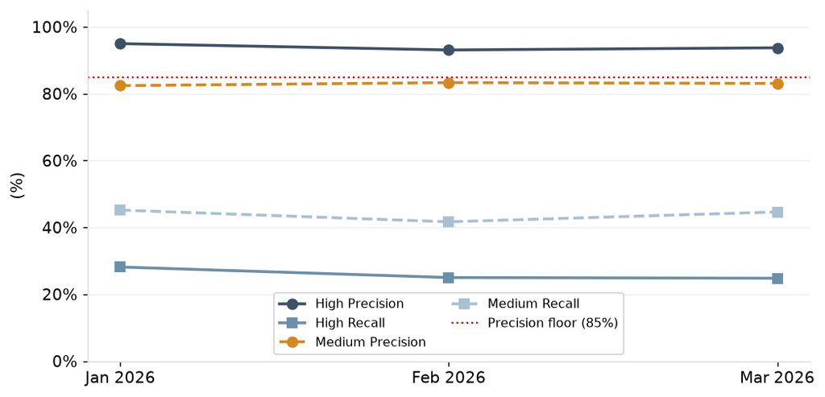

| Period | Scored | High Prec. | High Rec. | Med Prec. | Med Rec. |
| --- | --- | --- | --- | --- | --- |
| Jan 2026 | 270 | 95.0% | 28.1% | 82.4% | 45.2% |
| Feb 2026 | 206 | 93.1% | 25.0% | 83.3% | 41.7% |
| Mar 2026 | 219 | 93.8% | 24.8% | 83.1% | 44.6% |

Risk-Tier Mix by Period

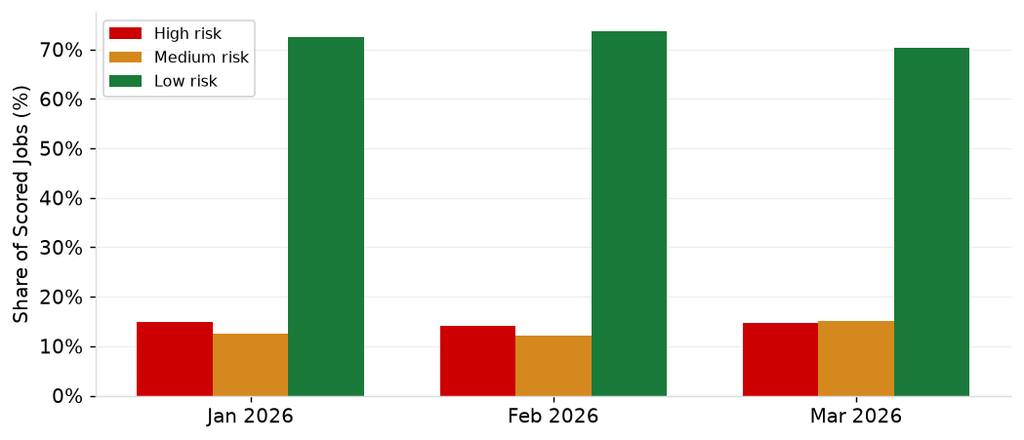

Risk-tier mix shows the operational load each period places on the floor team. Useful for calibrating review capacity against the High-risk count.

Section 3

## Target Drift

Actual defect rate per period versus the training baseline, as a rate comparison rather than a distribution distance, which is more interpretable for a binary outcome. A material shift signals the shop's underlying quality profile has changed, which can affect calibration even when inputs are stable.

Actual Defect Rate vs Training Baseline

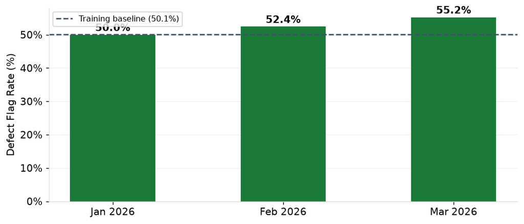

| Period | Actual Rate | Baseline | Δ | Status |
| --- | --- | --- | --- | --- |
| Jan 2026 | 50.0% | 50.1% | 0.1% | ✓ Stable |
| Feb 2026 | 52.4% | 50.1% | 2.3% | ✓ Stable |
| Mar 2026 | 55.2% | 50.1% | 5.1% | ✓ Stable |

Section 4

## Prediction Drift

Distribution of the model's predicted probabilities versus the validation-set reference, measured with the same distance method used for features. This is a label-free early indicator: it catches the model behaving differently regardless of which input moved. Here it corroborates the performance read rather than leading it.

Prediction-Drift Distance by Period

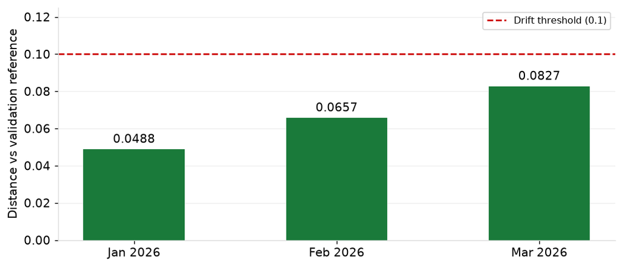

| Period | Distance | Threshold | Mean Score (ref→cur) | Status |
| --- | --- | --- | --- | --- |
| Jan 2026 | 0.0488 | 0.10 | 0.498 → 0.501 | ✓ Stable |
| Feb 2026 | 0.0657 | 0.10 | 0.498 → 0.508 | ✓ Stable |
| Mar 2026 | 0.0827 | 0.10 | 0.498 → 0.514 | ✓ Stable |

Score Distribution — Validation Reference vs Mar 2026

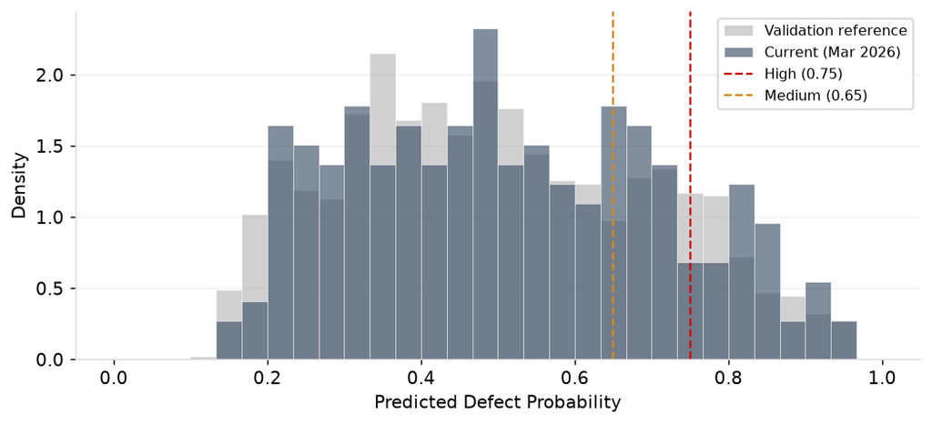

Section 5

## Feature Drift

Per-Feature Drift Distance (feature × period)

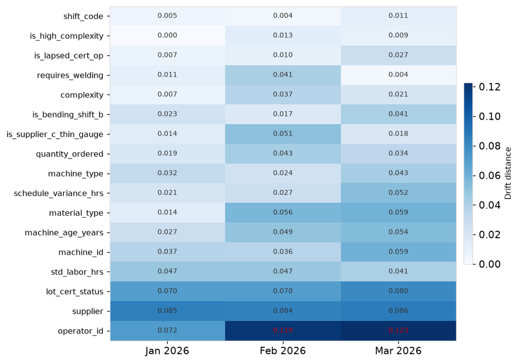

Latest-period detail (Mar 2026), ordered by distance:

| Feature | Type | Test | Drift Distance | Threshold | Status |
| --- | --- | --- | --- | --- | --- |
| operator_id | categorical | Jensen-Shannon distance | 0.1227 | 0.10 | ⚠ Drift |
| supplier | categorical | Jensen-Shannon distance | 0.0863 | 0.10 | ✓ Stable |
| lot_cert_status | categorical | Jensen-Shannon distance | 0.0803 | 0.10 | ✓ Stable |
| machine_id | categorical | Jensen-Shannon distance | 0.0592 | 0.10 | ✓ Stable |
| material_type | categorical | Jensen-Shannon distance | 0.0586 | 0.10 | ✓ Stable |
| machine_age_years | numerical | Wasserstein distance (normed) | 0.0540 | 0.10 | ✓ Stable |
| schedule_variance_hrs | numerical | Jensen-Shannon distance | 0.0525 | 0.10 | ✓ Stable |
| machine_type | categorical | Jensen-Shannon distance | 0.0431 | 0.10 | ✓ Stable |
| std_labor_hrs | numerical | Wasserstein distance (normed) | 0.0409 | 0.10 | ✓ Stable |
| is_bending_shift_b | interaction | Jensen-Shannon distance | 0.0409 | 0.10 | ✓ Stable |
| quantity_ordered | numerical | Wasserstein distance (normed) | 0.0338 | 0.10 | ✓ Stable |
| is_lapsed_cert_op | interaction | Jensen-Shannon distance | 0.0273 | 0.10 | ✓ Stable |
| complexity | categorical | Jensen-Shannon distance | 0.0207 | 0.10 | ✓ Stable |
| is_supplier_c_thin_gauge | interaction | Jensen-Shannon distance | 0.0185 | 0.10 | ✓ Stable |
| shift_code | categorical | Jensen-Shannon distance | 0.0111 | 0.10 | ✓ Stable |
| is_high_complexity | interaction | Jensen-Shannon distance | 0.0088 | 0.10 | ✓ Stable |
| requires_welding | categorical | Jensen-Shannon distance | 0.0036 | 0.10 | ✓ Stable |

Section 6

## Data Quality

Null rates, cardinality, and unseen categories for the latest scoring period. Unseen categories are absorbed by the model's `unknown_value=-1` encoding but reduce prediction quality for affected jobs.

Feature Null Rates — Mar 2026

[figure not shown]

| Feature | Null Rate | Unique Values | New Categories |
| --- | --- | --- | --- |
| machine_type | 0.0% | 4 | — |
| machine_id | 0.0% | 7 | — |
| shift_code | 0.0% | 2 | — |
| operator_id | 0.0% | 20 | — |
| complexity | 0.0% | 3 | — |
| material_type | 0.0% | 7 | — |
| supplier | 0.0% | 4 | — |
| lot_cert_status | 0.0% | 3 | — |
| requires_welding | 0.0% | 2 | — |
| machine_age_years | 0.0% | 7 | — |
| std_labor_hrs | 0.0% | 34 | — |
| quantity_ordered | 0.0% | 21 | — |
| schedule_variance_hrs | 0.0% | 3 | — |
| is_bending_shift_b | 0.0% | 2 | — |
| is_high_complexity | 0.0% | 2 | — |
| is_supplier_c_thin_gauge | 0.0% | 2 | — |
| is_lapsed_cert_op | 0.0% | 2 | — |

Section 7

## Monitoring Log

Model version history and run metadata for traceability.

| Version | Trained | Type | Val ROC-AUC | Stage |
| --- | --- | --- | --- | --- |
| v1 | 2026-06-17 | Xgboost | 0.7446 | Archived |
| v2 | 2026-06-20 | Xgboost | 0.7446 | Archived |
| v3 | 2026-06-24 | Xgboost | 0.7446 | Archived |
| v4 ← current | 2026-06-24 | Xgboost | 0.7446 | Production |

**Note on data.** These periods are generated from a single simulation seed, so genuine drift is expected to read near zero across all layers and performance is expected to be roughly stable. The report demonstrates the monitoring apparatus and decision logic; it is not a claim that this dataset is drifting.

**MLflow run:** 699919a1651e43d5b1d6d8122e28127b · **Registry:** defect_risk_scorer v4 (Production) · **Generated:** 2026-07-09 15:06